# Generating Quotes from The Office show

- Name: Akshara Shukla
- Class: AI7

## Introduction

For the first ANN exercise for this semester, I will be building an AI that will generate quotes using the hit The Office sitcom. The inspiration for this assignment comes after rewatching the show multiple times and it has been a project that I have been personally been waiting to try. In this notebook, the following steps will be described:

- Preparing the data,
- Analysing and visualising the data,
- Cleaning the data,
- Selecting features,
- Apply some callback functions
- Training your Machine learning algorithm,
- Applying the machine learning algorithm
- Evaluating its results
- and, generating new quotes

Firstly, lets import the required libraries.

```python
import pandas as pd
import numpy as np
import matplotlib
import matplotlib.pyplot as plt
import seaborn as sns
from wordcloud import WordCloud
import re

from keras.preprocessing.text import Tokenizer
import keras.utils as ku
from keras import layers
from keras.preprocessing.sequence import pad_sequences
from keras.models import Sequential, Model
from keras.layers.embeddings import Embedding
from keras.models import model_from_json
from keras.layers import Input, Activation, Dense, Dropout
from keras.layers import LSTM, Bidirectional
from keras.callbacks import EarlyStopping


print('numpy version:', np.__version__)
print('pandas version:', pd.__version__)
print('matplotlib version:', sns.__version__)

%matplotlib inline
```

```
numpy version: 1.18.5
pandas version: 1.1.4
matplotlib version: 0.11.1
```

## Preparing the data

For this, we will be using this dataset from kaggle. You can access it [here.](https://www.kaggle.com/datasets/fabriziocominetti/the-office-lines?resource=download) It includes all the lines spoken from each character in all the episodes throughout the course of the running of the show.

```python
df = pd.read_csv('the-office_lines.csv')
```

```python
df.head()
```

|  | Unnamed: 0 | Character | Line | Season | Episode_Number |
| --- | --- | --- | --- | --- | --- |
| 0 | 0 | Michael | All right Jim. Your quarterlies look very goo... | 1 | 1 |
| 1 | 1 | Jim | Oh, I told you. I couldn’t close it. So… | 1 | 1 |
| 2 | 2 | Michael | So you’ve come to the master for guidance? Is... | 1 | 1 |
| 3 | 3 | Jim | Actually, you called me in here, but yeah. | 1 | 1 |
| 4 | 4 | Michael | All right. Well, let me show you how it’s don... | 1 | 1 |

## Analysing the data

```python
df = df.loc[:,('Character','Line')]
df.rename(columns = {'Line':'Quotes'}, inplace = True)
```

```python
def exploratory_data_analysis(df):
    '''
    Function exploratory_data_analysis: This gives the data types, shape and unique characters that are present in the dataset.
    Parameters:
    a) df: Name of the dataset
    '''
    info = df.info()
    shape = df.shape
    unique_characters = len(df['Character'].unique())
    print(f'There are a total of {unique_characters} characters present in the show who say something.')

    return info, shape, unique_characters
```

```python
exploratory_data_analysis(df)
```

```
<class 'pandas.core.frame.DataFrame'>
RangeIndex: 58721 entries, 0 to 58720
Data columns (total 2 columns):
 #   Column     Non-Null Count  Dtype
---  ------     --------------  -----
 0   Character  58721 non-null  object
 1   Quotes     58721 non-null  object
dtypes: object(2)
memory usage: 917.6+ KB
There are a total of 780 characters present in the show who say something.
```

```
(None, (58721, 2), 780)
```

```
[]
```

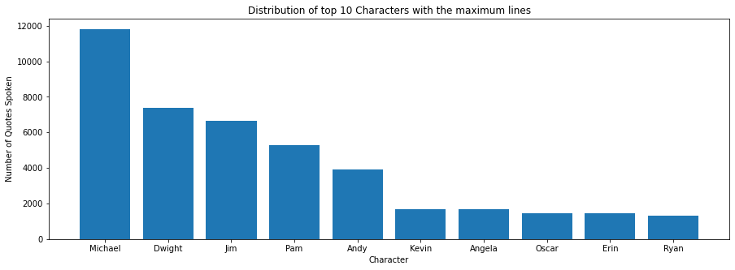

```python
max_lines_spoken = df.groupby('Character').agg({'Quotes':'count'}).reset_index().sort_values('Quotes',ascending=False)[:10]

fig=plt.figure(figsize=(15, 5))
plt.bar(max_lines_spoken['Character'], max_lines_spoken['Quotes']);
plt.xlabel('Character')
plt.ylabel('Number of Quotes Spoken')
plt.title('Distribution of top 10 Characters with the maximum lines')

plt.plot()
```

```python
#We are going to replace all the special characters with a ''.
#The ^0-9A-Za-z expression includes all the values except 0-9 and unnecesary alphabetic. Therefore, keeping only the alphabets in the strings
#initially.

df['Quotes']= df['Quotes'].str.replace(r'[^0-9A-Za-z ,\"\',]+', '')
df.head()
```

|  | Character | Quotes |
| --- | --- | --- |
| 0 | Michael | All right Jim Your quarterlies look very good... |
| 1 | Jim | Oh, I told you I couldnt close it So |
| 2 | Michael | So youve come to the master for guidance Is t... |
| 3 | Jim | Actually, you called me in here, but yeah |
| 4 | Michael | All right Well, let me show you how its done |

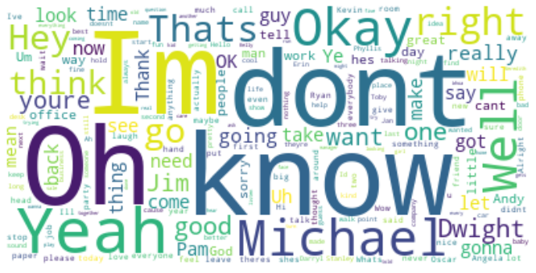

```python
fig=plt.figure(figsize=(20, 6))

# Creating word_cloud with text as argument in .generate() method
text3 = ' '.join(df['Quotes'])
wordcloud = WordCloud(collocations = False, background_color = 'white').generate(text3)
# Display the generated Word Cloud
plt.imshow(wordcloud, interpolation='bilinear')
plt.axis("off")
plt.show()
```

### EDA Analysis

From our EDA analysis, we can conclude that `Michael` was the character with the most lines spoken in the season. While, the top most said word are Im, Oh, Know, Michael, Thats and so on as they as visible in the wordcloud generated above. So far, I would agree with the results since these words are common but so is the character.

## Preparing the Data

```python
df.loc[df['Character'].isin(['Michael'])]
quotes = df['Quotes'].drop_duplicates()
quotes = quotes.sample(3000)
quotes = list(quotes)
quotes[:1]
```

```
[' Mmhm Im a magical fairy who floated into your office to bring a little bit of magic into your lives, to give you all raises  ']
```

For tokenization, I will be using the keras tokenizer. This is because during my internship I have used the BERT tokenizer and now I want to analyse how this one works with textual data.

It first uses *.fit_on_texts()* to create a dictionary of the unique words in the data and stores its frequencies. Based on the index value, it assigns an integer value which is also used for padding the sentence.

Then, it uses *.texts_to_sequences()* which is passed through each line in the generated corpus and converts them to a sequences of integer values which can be used as the input to our model.

```python
# Tokenization
tokenizer = Tokenizer()

# Function to create the sequences
def create_sequences(corpus):
    '''
    Function create_sequences: Takes in the quotes data and tokenizes them to make ready to be the input to our model.
    Parameters:
    a) corpus: This is cleaned quotes column from our dataset
    '''

    #tokenizing the individual texts
    tokenizer.fit_on_texts(corpus)
    total_words = len(tokenizer.word_index) + 1 #+1 because token ids start from 0
    print(f"Total unique words in our generated corpus: {total_words}")

    #now converting the corpus into a flat values that can be used as an input to our model
    input_sentences = []
    for line in corpus:
        gen_sequences = tokenizer.texts_to_sequences([line])[0]
        for i in range(1, len(gen_sequences)):
            ngram_seq = gen_sequences[:i+1]
            input_sentences.append(ngram_seq)

    return input_sentences, total_words

# Looking at the first sequence of the sentence
input_sentences, total_words = create_sequences(quotes)
input_sentences[:5]
```

```
Total unique words in our generated corpus: 4938
```

```
[[1394, 17],
 [1394, 17, 5],
 [1394, 17, 5, 2106],
 [1394, 17, 5, 2106, 2107],
 [1394, 17, 5, 2106, 2107, 95]]
```

Now, that we have the data in unique integer values, it's required to pad them i.e., making each input_sequence with same lenth. I will pad both the sentences and it's predictor using the *pad_sequence* function from keras library.

```python
# Generating predictors and labels from the padded sequences
def input_data_values(input_sentences):
    '''
    Function input_data_values: Takes in the array of sentences and makes them all of one length. Also, extracts the predictors and labels for each sentences in our data.
    Parameters:
    a) input_sentences: This is the output of the previous function i.e., the array of sentences.
    '''
    maxlen = max([len(x) for x in input_sentences])
    input_sentences = pad_sequences(input_sentences, maxlen=maxlen)

    #extracting the predictors and labels from our input sequences
    predictors, label = input_sentences[:, :-1], input_sentences[:, -1]

    #making the next predicted word in the sequence to a binary matrix
    #this is vital for assigning number for next work prediction
    label = ku.to_categorical(label, num_classes=total_words)
    return predictors, label, maxlen

predictors, label, maxlen = input_data_values(input_sentences)
predictors[:1], label[:1], maxlen
```

```
(array([[   0,    0,    0,    0,    0,    0,    0,    0,    0,    0,    0,
            0,    0,    0,    0,    0,    0,    0,    0,    0,    0,    0,
            0,    0,    0,    0,    0,    0,    0,    0,    0,    0,    0,
            0,    0,    0,    0,    0,    0,    0,    0,    0,    0,    0,
            0,    0,    0,    0,    0,    0,    0,    0,    0,    0,    0,
            0,    0,    0,    0,    0,    0,    0,    0,    0,    0,    0,
            0,    0,    0,    0,    0,    0,    0,    0,    0,    0,    0,
            0,    0,    0,    0,    0,    0,    0,    0,    0,    0,    0,
            0,    0,    0,    0,    0,    0,    0,    0,    0,    0,    0,
            0,    0,    0,    0,    0,    0,    0,    0,    0,    0,    0,
            0,    0,    0,    0,    0,    0,    0,    0,    0,    0,    0,
            0,    0,    0,    0,    0,    0,    0,    0,    0,    0,    0,
            0,    0,    0,    0,    0,    0,    0,    0,    0,    0,    0,
            0,    0,    0,    0,    0,    0,    0,    0,    0,    0,    0,
            0,    0,    0,    0,    0, 1394]]),
 array([[0., 0., 0., ..., 0., 0., 0.]], dtype=float32),
 161)
```

### Callbacks

I will be using the *earlystop* callback function. It will monitor the 'loss' value per each epoch and if the difference between the losses is 0 for next 4 epochs, it will stop the training. This helps in solving the issue of overfitting.

```python
#EarlyStop Callback
earlystop = EarlyStopping(monitor = 'loss',
                         min_delta = 0,    #training process will be stopped if the absolute change of loss is less than 0
                         patience = 4,
                         verbose = 1,
                         restore_best_weights=True)
```

## Fine-tuning the Hyperparameters

Since our quote generator is similar to the process of text generation, I will be using the Long - Short Term Memory model. It's a recurrent neural network model (RNN) that is a type of Artificial Neural Networks that works on the principle of gathering data and storing it as memory.

It's a type of ANN as it processes the data similar as to the human brain and processes the data in both ways.

1. Input Layer : Takes the sequence of words as input
2. LSTM Layer : Computes the output using LSTM units. We will be experimenting with this number in our hyper-parameter tuning.
3. Dropout Layer : A regularisation layer which randomly turns-off the activations of some neurons in the LSTM layer. It helps in preventing over fitting.
4. Output Layer : Computes the probability of the best possible next word as output

```python
def model_tune(embedding_dim,neurons,dropout,optimizer):
'''
Function model_tune: This function takes in specific parameters which will be used to train our LSTM model.
Parameters:
The parameters are described below with the two values which will be used for training.
'''

    emdedding_dim = embedding_dim
    model = Sequential()

    #the input embedding layer
    model.add(layers.Embedding(total_words, embedding_dim, input_length = maxlen))

    #the LSTM and one hidden layer
    model.add(layers.LSTM(neurons, dropout = dropout))
    model.add(Dropout(0.2))

    #the output layer which shall give us the next word in the sentence
    model.add(layers.Dense(total_words,activation = 'softmax'))

    #compiling the model
    model.compile(loss = 'categorical_crossentropy', optimizer = optimizer)
    model.summary()

    #fitting and training
    model.fit(predictors, label,
              epochs=10,
              batch_size=64,
              callbacks = earlystop)

    #calculating the lost
    print(model.evaluate(predictors, label))

    return model
```

The function built above `model_tune`, trains our model with different values for the following hyperparameters. It gives us the loss value per epoch and the total average loss value for the next predicted word.

1. **Embedding_dim**: This parameter is the total or maximum number of feature dimensions that the input will be designed for. This is important because it makes sure that all the input sentences/word in our corpus is of the same length or dimension. To determine this number, the formula used is from this [link](https://ai.stackexchange.com/questions/28564/how-to-determine-the-embedding-size)
2. **Neurons**: The neurons are the number of LSTM units that will be learning from the data and transfering to the next layer. We will be experimentng with 100 and 128.
3. **Dropout**: This is the rate at which the model will randomly shut or ignored the output features. According to this [link](https://machinelearningmastery.com/dropout-for-regularizing-deep-neural-networks/#:~:text=A%20good%20value%20for%20dropout,rate%2C%20such%20as%20of%200.8.), the optimal value for the dropout rate is between 0.5 and 0.8. We will be experimenting with two values: 0.2 and 0.5
4. **Optimizer**: This is the value that is reponsible for the balanced learning of the model. It balances the overall weights and learning rate. Therefore, it helps in making sure the loss value decreases and improves the overall accuracy. According to think [link](https://machinelearningmastery.com/adam-optimization-algorithm-for-deep-learning/), it suggests that *adam* is the most optimal optimizer but for the interest, I'll try it out with rmsprop as well.